# Life-history traits explain variation in the larval dispersal potential of corals - systematic review figure code

## Meta-analysis models and figures

Code to re-produce our meta-analysis and to produce figure 4

### Packages

Code to load (and install if necessary) the packages needed. (Remove “#”s to install packages.)

```r
#  install.packages("tidyverse")
library(tidyverse)

# install.packages("metafor")
library(metafor)

# install.packages("rotl")
library(rotl)

# install.packages("ape")
library(ape)
```

### Data

Read in the effect size data

```r
#Review data
model_data_raw <- read_csv("data/coral-modelling-data.csv")
```

Separate the mean settlement and survival times effect sizes into separate dataframes

```r
coral_settle <- model_data_raw %>%
  drop_na(pld_av_comp_effectsize_d)

coral_survival <- model_data_raw %>%
  drop_na(pld_av_mort_effectsize_d)
```

### Data wrangling - computing phylogeny

Make a phylogenetic correlation matrix for the species with competency data (can be slow!)

```r
#Create list of species for meta-analysis
settle_splist <- coral_settle %>%
  distinct(species_accepted, .keep_all = FALSE)
#Make list a vector
settle_splist <- settle_splist$species_accepted

#Get ottd ids for species (this can take a minute)
ott_ids_settle <- tnrs_match_names(settle_splist) #%>%
  #drop_na(ott_id)

print(ott_ids_settle)
```

```
##                 search_string                                      unique_name
## 1         seriatopora hystrix                              Seriatopora hystrix
## 2      seriatopora caliendrum                           Seriatopora caliendrum
## 3       stylophora pistillata                            Stylophora pistillata
## 4       montastraea cavernosa                            Montastraea cavernosa
## 5         orbicella faveolata                              Orbicella faveolata
## 6      pocillopora damicornis                           Pocillopora damicornis
## 7                favia fragum                                     Favia fragum
## 8      balanophyllia europaea                           Balanophyllia europaea
## 9        acropora cervicornis                             Acropora cervicornis
## 10      astroides calycularis                            Astroides calycularis
## 11        dentomuricea meteor                              Dentomuricea meteor
## 12        paramuricea clavata                              Paramuricea clavata
## 13    antillogorgia americana                          Antillogorgia americana
## 14       eunicella singularis                             Eunicella singularis
```

[output cut: 141 more lines]

```r
#They all match, yay

#Make tree
settle_tree <- tol_induced_subtree(ott_ids_settle$ott_id)
```

```
## Progress [---------------------------------] 0/171 (  0%) ?sProgress [==============================] 171/171 (100%)  0s
```

[output not shown]

[figure not shown]

```r
plot(settle_tree)
```

```r
#Make tree ultrametric
settle_tree <- compute.brlen(settle_tree)

#Make a phylogenetic correlation matrix from the tree
settle_PCM <- vcv(settle_tree, corr = TRUE)
```

Save a plot of the tree

[figure not shown]

```r
plot(settle_tree)
```

```r
png(filename = "figures/settlement_tree.png",
    width = 900, height = 1500)
plot(settle_tree)
dev.off()
```

Match the ottd IDs to the settlement data

```r
#Add the species OTTD IDs to link to the phylogenetic correlation matrix
settle_link <- subset(ott_ids_settle, select = c("search_string", "unique_name", "ott_id"))
phy_settle <- coral_settle %>%
  mutate(low_species = tolower(species_accepted)) %>%
  mutate(low_genus = tolower(genus_accepted))
phy_settle <- left_join(x = phy_settle, y = settle_link, by = join_by(low_species == search_string))

#change the unique name for A. millepora to put underscores in the bracketed bit
phy_settle <- phy_settle %>%
  mutate(unique_name = case_when(
    grepl("millepora", unique_name) ~ "Acropora_millepora_(species_in_domain_Eukaryota)",
    .default = unique_name
  ))

phy_settle <- phy_settle %>%
  mutate(species.phy = sub(" ", "_", (paste(unique_name, paste("ott", phy_settle$ott_id, sep = ""), sep = "_"))))
```

Now do the same for the survival data

```r
#Create list of species for meta-analysis
surv_splist <- coral_survival %>%
  distinct(species_accepted, .keep_all = FALSE)
#Make list a vector
surv_splist <- surv_splist$species_accepted

#Get ottd ids for species (this can take a minute)
ott_ids_surv <- tnrs_match_names(surv_splist) #%>%
  #drop_na(ott_id)

print(ott_ids_surv)
```

```
##               search_string                                      unique_name
## 1       orbicella faveolata                              Orbicella faveolata
## 2       dentomuricea meteor                              Dentomuricea meteor
## 3       paramuricea clavata                              Paramuricea clavata
## 4      eunicella singularis                             Eunicella singularis
## 5       cyphastrea japonica                              Cyphastrea japonica
## 6        acropora millepora Acropora millepora (species in domain Eukaryota)
## 7     pocillopora verrucosa                            Pocillopora verrucosa
## 8         pocillopora acuta                                Pocillopora acuta
## 9      acropora cervicornis                             Acropora cervicornis
## 10         acropora palmata                                 Acropora palmata
## 11          acropora tenuis                                  Acropora tenuis
## 12    tubastraea tagusensis                            Tubastraea tagusensis
## 13      tubastraea coccinea                              Tubastraea coccinea
## 14      acropora spathulata                              Acropora spathulata
```

[output cut: 65 more lines]

```r
#They all match, yay

#Make tree
surv_tree <- tol_induced_subtree(ott_ids_surv$ott_id)
```

```
## Progress [---------------------------------] 0/122 (  0%) ?sProgress [==============================] 122/122 (100%)  0s
```

[output not shown]

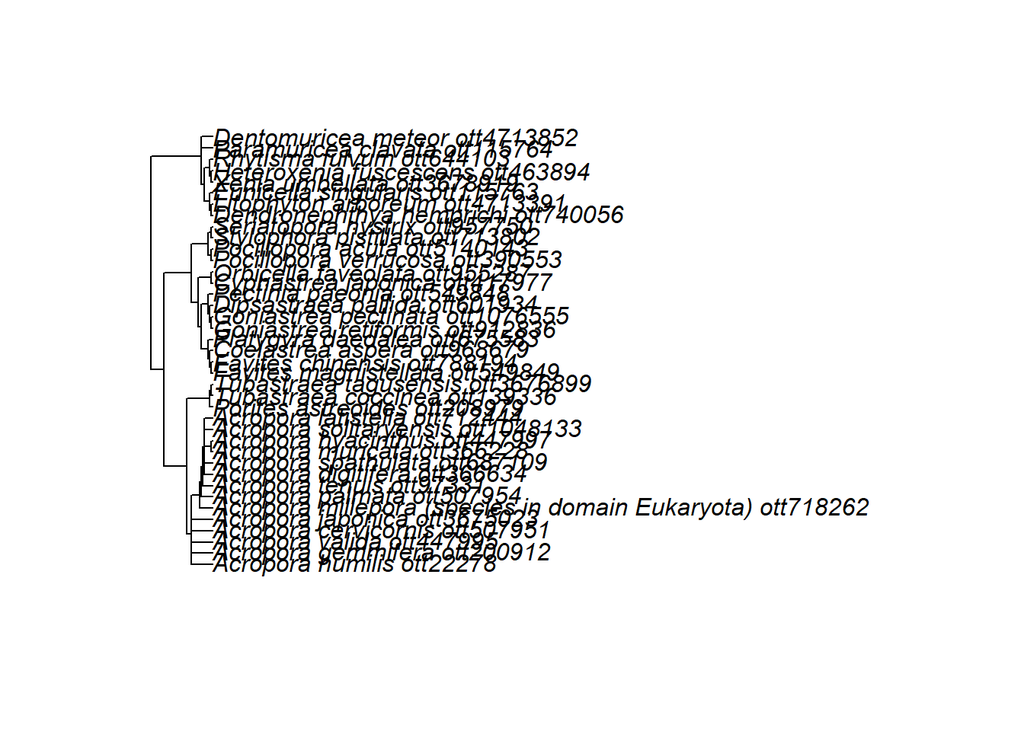

```r
plot(surv_tree)
```

```r
#Make tree ultrametric
surv_tree <- compute.brlen(surv_tree)

#Make a phylogenetic correlation matrix from the tree
surv_PCM <- vcv(surv_tree, corr = TRUE)
```

Save a plot of the tree

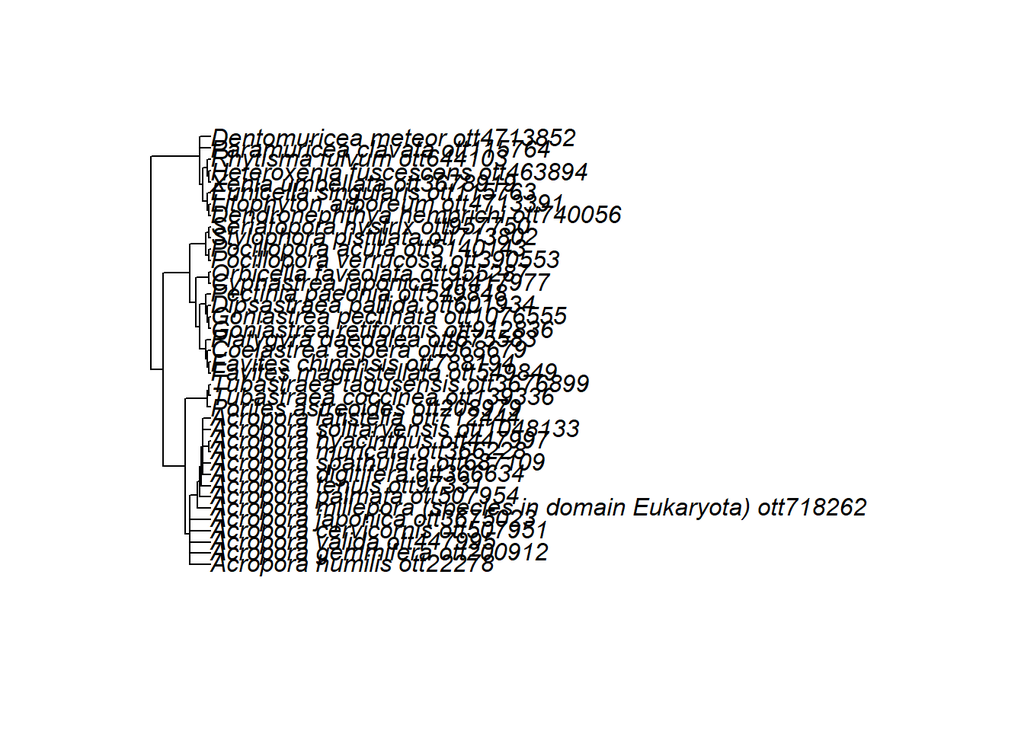

```r
plot(surv_tree)
```

```r
png(filename = "figures/survival_tree.png",
    width = 900, height = 900)
plot(surv_tree)
dev.off()
```

Match the ottd IDs to the survival data

```r
#Add the species OTTD IDs to link to the phylogenetic correlation matrix
surv_link <- subset(ott_ids_surv, select = c("search_string", "unique_name", "ott_id"))
phy_surv <- coral_survival %>%
  mutate(low_species = tolower(species_accepted)) %>%
  mutate(low_genus = tolower(genus_accepted))
phy_surv <- left_join(x = phy_surv, y = surv_link, by = join_by(low_species == search_string))

#change the unique name for A. millepora to put underscores in the bracketed bit
phy_surv <- phy_surv %>%
  mutate(unique_name = case_when(
    grepl("millepora", unique_name) ~ "Acropora_millepora_(species_in_domain_Eukaryota)",
    .default = unique_name
  ))

phy_surv <- phy_surv %>%
  mutate(species.phy = sub(" ", "_", (paste(unique_name, paste("ott", phy_surv$ott_id, sep = ""), sep = "_"))))
```

Make reproductive mode and morphology factors so the models work properly

```r
#Reproductive mode
phy_settle$spawn_mode <- as.factor(phy_settle$spawn_mode)
phy_surv$spawn_mode <- as.factor(phy_surv$spawn_mode)

#Morphology
phy_settle$growth_form_cat <- as.factor(phy_settle$growth_form_cat)
phy_surv$growth_form_cat <- as.factor(phy_surv$growth_form_cat)
```

Create dataframes with geographic variables for models of geographic realm and latitude, for both settlement and survival time effect sizes

```r
# Settlement
geog_settle <- phy_settle %>%
  mutate(zone = case_when(
    grepl("Temperate", biogeog_realm) ~ "temperate",
    grepl("Tropical", biogeog_realm) ~ "tropical",
    grepl("Indo-Pacific", biogeog_realm) ~ "tropical",
    grepl("Arctic", biogeog_realm) ~ "polar",
    grepl("Southern Ocean", biogeog_realm) ~ "polar")) %>% # assign realms to tropical/temperate
  mutate(med_lat = (abs(latmin) + abs(latmax))/2) %>% # determine latitude of the study area's midpoint
  filter(biogeog_realm != "aquarium_culture") # remove effect sizes for observations with unknown locations

# Survival
geog_surv <- phy_surv %>%
  mutate(zone = case_when(
    grepl("Temperate", biogeog_realm) ~ "temperate",
    grepl("Tropical", biogeog_realm) ~ "tropical",
    grepl("Indo-Pacific", biogeog_realm) ~ "tropical",
    grepl("Arctic", biogeog_realm) ~ "polar",
    grepl("Southern Ocean", biogeog_realm) ~ "polar",
  )) %>%
  mutate(med_lat = (abs(latmin) + abs(latmax))/2) %>%
  filter(biogeog_realm != "aquarium_culture")
```

### Random-effects meta-analysis models: Settlement time

Run random-effects meta-analysis models of mean larval settlement time.

Random-effects model - observation nested in study

```r
# Construct model
random_study_mod_SETTLE <- rma.mv(yi = pld_av_comp_effectsize_d, V = ((pld_av_comp_effect_sd)^2), data = phy_settle, random = list(~ 1|acc_id/obs_id)) # use mean settlement time as effect size, weight by variance in the mean, use observation as a random effect nested within study

# Summarise results
summary(random_study_mod_SETTLE)
```

```
##
## Multivariate Meta-Analysis Model (k = 137; method: REML)
##
##    logLik   Deviance        AIC        BIC       AICc
## -526.2998  1052.5996  1058.5996  1067.3376  1058.7814
##
## Variance Components:
##
##              estim    sqrt  nlvls  fixed         factor
## sigma^2.1  95.6653  9.7809     57     no         acc_id
## sigma^2.2  79.4380  8.9128    137     no  acc_id/obs_id
##
## Test for Heterogeneity:
## Q(df = 136) = 340922.0160, p-val < .0001
##
## Model Results:
##
## estimate      se    zval    pval    ci.lb    ci.ub
##  13.9847  1.6024  8.7272  <.0001  10.8440  17.1254  ***
##
## ---
## Signif. codes:  0 '***' 0.001 '**' 0.01 '*' 0.05 '.' 0.1 ' ' 1
```

Random-effects model - observation nested in study with phylogenetic control

```r
# Model
random_phylo_mod_SETTLE <- rma.mv(yi = pld_av_comp_effectsize_d, V = ((pld_av_comp_effect_sd)^2), data = phy_settle, random = list(~ 1|acc_id/obs_id, ~1|species.phy), R = list(species.phy = settle_PCM)) # add species as a random effect, and link it to the relevant phylogenetic correlation matrix

# Results
summary(random_phylo_mod_SETTLE)
```

```
##
## Multivariate Meta-Analysis Model (k = 137; method: REML)
##
##    logLik   Deviance        AIC        BIC       AICc
## -522.7057  1045.4113  1053.4113  1065.0619  1053.7167
##
## Variance Components:
##
##              estim    sqrt  nlvls  fixed         factor    R
## sigma^2.1  51.3539  7.1662     57     no         acc_id   no
## sigma^2.2  81.3693  9.0205    137     no  acc_id/obs_id   no
## sigma^2.3  29.0649  5.3912     76     no    species.phy  yes
##
## Test for Heterogeneity:
## Q(df = 136) = 340922.0160, p-val < .0001
##
## Model Results:
##
## estimate      se    zval    pval   ci.lb    ci.ub
##  14.9728  3.2435  4.6163  <.0001  8.6158  21.3299  ***
##
## ---
## Signif. codes:  0 '***' 0.001 '**' 0.01 '*' 0.05 '.' 0.1 ' ' 1
```

AIC comparison shows that controlling for phylogeny provides better fit

### Mixed-effects meta-regressions: Settlement time

Combined reproductive mode and morphology model

```r
repro_morpho_mod_SETTLE <- rma.mv(yi = pld_av_comp_effectsize_d, V = ((pld_av_comp_effect_sd)^2), data = phy_settle, mods = ~ spawn_mode*growth_form_cat, random = list(~ 1|acc_id/obs_id, ~1|species.phy), R = list(species.phy = settle_PCM))
summary(repro_morpho_mod_SETTLE)
```

```
##
## Multivariate Meta-Analysis Model (k = 137; method: REML)
##
##    logLik   Deviance        AIC        BIC       AICc
## -488.6115   977.2231   999.2231  1030.6810  1001.4795
##
## Variance Components:
##
##              estim    sqrt  nlvls  fixed         factor    R
## sigma^2.1  30.6684  5.5379     57     no         acc_id   no
## sigma^2.2  87.8907  9.3750    137     no  acc_id/obs_id   no
## sigma^2.3   0.0000  0.0016     76     no    species.phy  yes
##
## Test for Residual Heterogeneity:
## QE(df = 129) = 203185.1027, p-val < .0001
##
## Test of Moderators (coefficients 2:8):
## QM(df = 7) = 39.9532, p-val < .0001
##
## Model Results:
##
##                                                   estimate      se     zval
## intrcpt                                            13.8730  1.9540   7.0997
## spawn_modebrooding                                 -8.6094  3.2395  -2.6576
## growth_form_catdomed                               -0.8846  2.4030  -0.3681
## growth_form_caterect branched                      13.8487  5.3925   2.5681
## growth_form_cathorizontal unbranched                4.6586  5.7295   0.8131
## growth_form_catplating                              0.2199  3.7009   0.0594
## spawn_modebrooding:growth_form_catdomed             4.3612  4.9527   0.8806
## spawn_modebrooding:growth_form_caterect branched    9.9996  6.7170   1.4887
##                                                     pval     ci.lb    ci.ub
## intrcpt                                           <.0001   10.0432  17.7028
## spawn_modebrooding                                0.0079  -14.9587  -2.2601
## growth_form_catdomed                              0.7128   -5.5945   3.8253
## growth_form_caterect branched                     0.0102    3.2796  24.4179
## growth_form_cathorizontal unbranched              0.4162   -6.5710  15.8881
## growth_form_catplating                            0.9526   -7.0338   7.4736
## spawn_modebrooding:growth_form_catdomed           0.3785   -5.3459  14.0684
## spawn_modebrooding:growth_form_caterect branched  0.1366   -3.1654  23.1647
##
## intrcpt                                           ***
## spawn_modebrooding                                 **
## growth_form_catdomed
## growth_form_caterect branched                       *
## growth_form_cathorizontal unbranched
## growth_form_catplating
## spawn_modebrooding:growth_form_catdomed
## spawn_modebrooding:growth_form_caterect branched
##
## ---
## Signif. codes:  0 '***' 0.001 '**' 0.01 '*' 0.05 '.' 0.1 ' ' 1
```

Model for biogeographic realm

```r
realm_mod_SETTLE <- rma.mv(yi = pld_av_comp_effectsize_d, V = ((pld_av_comp_effect_sd)^2), data = geog_settle, mods = ~biogeog_realm, random = list(~1|acc_id/obs_id, ~1|species.phy), R = list(species.phy = settle_PCM))

summary(realm_mod_SETTLE)
```

```
##
## Multivariate Meta-Analysis Model (k = 135; method: REML)
##
##    logLik   Deviance        AIC        BIC       AICc
## -487.1304   974.2607   996.2607  1027.5468   998.5564
##
## Variance Components:
##
##              estim    sqrt  nlvls  fixed         factor    R
## sigma^2.1  50.0564  7.0751     57     no         acc_id   no
## sigma^2.2  83.6289  9.1449    135     no  acc_id/obs_id   no
## sigma^2.3  25.3279  5.0327     76     no    species.phy  yes
##
## Test for Residual Heterogeneity:
## QE(df = 127) = 186649.8399, p-val < .0001
##
## Test of Moderators (coefficients 2:8):
## QM(df = 7) = 8.4348, p-val = 0.2958
##
## Model Results:
##
##                                           estimate       se     zval    pval
## intrcpt                                    11.2841   3.7209   3.0326  0.0024
## biogeog_realmEastern Indo-Pacific           0.3144  11.2984   0.0278  0.9778
## biogeog_realmTemperate Australasia          4.5490   6.9277   0.6566  0.5114
## biogeog_realmTemperate Northern Atlantic   11.4047   4.9863   2.2872  0.0222
## biogeog_realmTemperate Northern Pacific    -3.0618   6.1660  -0.4966  0.6195
## biogeog_realmTemperate South America        6.1243   8.3244   0.7357  0.4619
## biogeog_realmTropical Atlantic              7.0832   4.2776   1.6559  0.0977
## biogeog_realmWestern Indo-Pacific           1.4607   4.4389   0.3291  0.7421
##                                              ci.lb    ci.ub
## intrcpt                                     3.9913  18.5769  **
## biogeog_realmEastern Indo-Pacific         -21.8300  22.4588
## biogeog_realmTemperate Australasia         -9.0291  18.1270
## biogeog_realmTemperate Northern Atlantic    1.6318  21.1777   *
## biogeog_realmTemperate Northern Pacific   -15.1470   9.0234
## biogeog_realmTemperate South America      -10.1911  22.4398
## biogeog_realmTropical Atlantic             -1.3007  15.4671   .
## biogeog_realmWestern Indo-Pacific          -7.2395  10.1608
##
## ---
## Signif. codes:  0 '***' 0.001 '**' 0.01 '*' 0.05 '.' 0.1 ' ' 1
```

Model for tropical/temperate region

```r
geog_mod_SETTLE <- rma.mv(yi = pld_av_comp_effectsize_d, V = ((pld_av_comp_effect_sd)^2), data = geog_settle, mods = ~zone, random = list(~1|acc_id/obs_id, ~1|species.phy), R = list(species.phy = settle_PCM))
summary(geog_mod_SETTLE)
```

```
##
## Multivariate Meta-Analysis Model (k = 135; method: REML)
##
##    logLik   Deviance        AIC        BIC       AICc
## -511.8941  1023.7882  1033.7882  1048.2399  1034.2606
##
## Variance Components:
##
##              estim    sqrt  nlvls  fixed         factor    R
## sigma^2.1  52.5775  7.2510     57     no         acc_id   no
## sigma^2.2  82.8126  9.1001    135     no  acc_id/obs_id   no
## sigma^2.3  26.7610  5.1731     76     no    species.phy  yes
##
## Test for Residual Heterogeneity:
## QE(df = 133) = 262496.2242, p-val < .0001
##
## Test of Moderators (coefficient 2):
## QM(df = 1) = 1.3380, p-val = 0.2474
##
## Model Results:
##
##               estimate      se     zval    pval     ci.lb    ci.ub
## intrcpt        17.5356  3.8382   4.5687  <.0001   10.0128  25.0583  ***
## zonetropical   -3.9453  3.4108  -1.1567  0.2474  -10.6302   2.7397
##
## ---
## Signif. codes:  0 '***' 0.001 '**' 0.01 '*' 0.05 '.' 0.1 ' ' 1
```

Model for latitude

```r
lat_mod_SETTLE <- rma.mv(yi = pld_av_comp_effectsize_d, V = ((pld_av_comp_effect_sd)^2), data = geog_settle, mods = ~med_lat, random = list(~1|acc_id/obs_id, ~1|species.phy), R = list(species.phy = settle_PCM))
summary(lat_mod_SETTLE)
```

```
##
## Multivariate Meta-Analysis Model (k = 132; method: REML)
##
##    logLik   Deviance        AIC        BIC       AICc
## -502.0003  1004.0005  1014.0005  1028.3382  1014.4844
##
## Variance Components:
##
##              estim    sqrt  nlvls  fixed         factor    R
## sigma^2.1  54.8371  7.4052     56     no         acc_id   no
## sigma^2.2  85.1164  9.2259    132     no  acc_id/obs_id   no
## sigma^2.3  26.5567  5.1533     76     no    species.phy  yes
##
## Test for Residual Heterogeneity:
## QE(df = 130) = 335475.6878, p-val < .0001
##
## Test of Moderators (coefficient 2):
## QM(df = 1) = 0.7748, p-val = 0.3787
##
## Model Results:
##
##          estimate      se    zval    pval    ci.lb    ci.ub
## intrcpt   10.2342  6.2960  1.6255  0.1041  -2.1058  22.5742
## med_lat    0.1688  0.1918  0.8802  0.3787  -0.2071   0.5448
##
## ---
## Signif. codes:  0 '***' 0.001 '**' 0.01 '*' 0.05 '.' 0.1 ' ' 1
```

### Random-effects meta-analysis models: Survival time

Random-effects model - observation nested in study

```r
random_study_mod_SURV <- rma.mv(yi = pld_av_mort_effectsize_d, V = ((pld_av_mort_effect_sd)^2), data = phy_surv, random = list(~ 1|acc_id/obs_id))

summary(random_study_mod_SURV)
```

```
##
## Multivariate Meta-Analysis Model (k = 57; method: REML)
##
##    logLik   Deviance        AIC        BIC       AICc
## -258.6485   517.2969   523.2969   529.3730   523.7585
##
## Variance Components:
##
##               estim     sqrt  nlvls  fixed         factor
## sigma^2.1  138.7716  11.7801     27     no         acc_id
## sigma^2.2  488.0013  22.0908     57     no  acc_id/obs_id
##
## Test for Heterogeneity:
## Q(df = 56) = 146345.7456, p-val < .0001
##
## Model Results:
##
## estimate      se    zval    pval    ci.lb    ci.ub
##  25.4495  3.9271  6.4805  <.0001  17.7526  33.1464  ***
##
## ---
## Signif. codes:  0 '***' 0.001 '**' 0.01 '*' 0.05 '.' 0.1 ' ' 1
```

Random-effects model - observation nested in study with phylogenetic control

```r
random_phylo_mod_SURV <- rma.mv(yi = pld_av_mort_effectsize_d, V = ((pld_av_mort_effect_sd)^2), data = phy_surv, random = list(~ 1|acc_id/obs_id, ~1|species.phy), R = list(species.phy = surv_PCM))

summary(random_phylo_mod_SURV)
```

```
##
## Multivariate Meta-Analysis Model (k = 57; method: REML)
##
##    logLik   Deviance        AIC        BIC       AICc
## -258.0800   516.1599   524.1599   532.2613   524.9442
##
## Variance Components:
##
##               estim     sqrt  nlvls  fixed         factor    R
## sigma^2.1  126.5439  11.2492     27     no         acc_id   no
## sigma^2.2  420.2521  20.5001     57     no  acc_id/obs_id   no
## sigma^2.3  164.4769  12.8249     39     no    species.phy  yes
##
## Test for Heterogeneity:
## Q(df = 56) = 146345.7456, p-val < .0001
##
## Model Results:
##
## estimate      se    zval    pval    ci.lb    ci.ub
##  26.4793  8.1214  3.2604  0.0011  10.5617  42.3970  **
##
## ---
## Signif. codes:  0 '***' 0.001 '**' 0.01 '*' 0.05 '.' 0.1 ' ' 1
```

AIC comparison shows that controlling for phylogeny does not provide better fit

### Mixed-effects meta-regressions: Survival time

Combined reproductive mode and morphology model

```r
repro_morpho_mod_SURV <- rma.mv(yi = pld_av_mort_effectsize_d, V = ((pld_av_mort_effect_sd)^2), data = phy_surv, mods = ~ spawn_mode*growth_form_cat, random = list(~ 1|acc_id/obs_id))
summary(repro_morpho_mod_SURV)
```

```
##
## Multivariate Meta-Analysis Model (k = 57; method: REML)
##
##    logLik   Deviance        AIC        BIC       AICc
## -225.8217   451.6434   471.6434   490.5616   477.4329
##
## Variance Components:
##
##               estim     sqrt  nlvls  fixed         factor
## sigma^2.1  130.2549  11.4129     27     no         acc_id
## sigma^2.2  486.2967  22.0521     57     no  acc_id/obs_id
##
## Test for Residual Heterogeneity:
## QE(df = 49) = 68948.8106, p-val < .0001
##
## Test of Moderators (coefficients 2:8):
## QM(df = 7) = 7.6109, p-val = 0.3682
##
## Model Results:
##
##                                                   estimate       se     zval
## intrcpt                                            18.9983   5.6888   3.3396
## spawn_modebrooding                                -13.4562  14.7302  -0.9135
## growth_form_catdomed                               15.3029   8.1922   1.8680
## growth_form_caterect branched                      16.4324  14.1127   1.1644
## growth_form_cathorizontal unbranched               13.3237  27.9372   0.4769
## growth_form_catplating                              9.9296  14.4713   0.6862
## spawn_modebrooding:growth_form_catdomed            -2.9394  20.9527  -0.1403
## spawn_modebrooding:growth_form_caterect branched   16.4221  22.2658   0.7375
##                                                     pval     ci.lb    ci.ub
## intrcpt                                           0.0008    7.8484  30.1481
## spawn_modebrooding                                0.3610  -42.3269  15.4144
## growth_form_catdomed                              0.0618   -0.7536  31.3594
## growth_form_caterect branched                     0.2443  -11.2280  44.0927
## growth_form_cathorizontal unbranched              0.6334  -41.4323  68.0796
## growth_form_catplating                            0.4926  -18.4337  38.2929
## spawn_modebrooding:growth_form_catdomed           0.8884  -44.0059  38.1270
## spawn_modebrooding:growth_form_caterect branched  0.4608  -27.2181  60.0623
##
## intrcpt                                           ***
## spawn_modebrooding
## growth_form_catdomed                                .
## growth_form_caterect branched
## growth_form_cathorizontal unbranched
## growth_form_catplating
## spawn_modebrooding:growth_form_catdomed
## spawn_modebrooding:growth_form_caterect branched
##
## ---
## Signif. codes:  0 '***' 0.001 '**' 0.01 '*' 0.05 '.' 0.1 ' ' 1
```

Model for biogeographic realm

```r
realm_mod_SURV <- rma.mv(yi = pld_av_mort_effectsize_d, V = ((pld_av_mort_effect_sd)^2), data = geog_surv, mods = ~biogeog_realm, random = list(~1|acc_id/obs_id))

summary(realm_mod_SURV)
```

```
##
## Multivariate Meta-Analysis Model (k = 55; method: REML)
##
##    logLik   Deviance        AIC        BIC       AICc
## -222.0862   444.1724   462.1724   479.0132   466.9093
##
## Variance Components:
##
##               estim     sqrt  nlvls  fixed         factor
## sigma^2.1  157.1963  12.5378     27     no         acc_id
## sigma^2.2  504.9103  22.4702     55     no  acc_id/obs_id
##
## Test for Residual Heterogeneity:
## QE(df = 48) = 60257.5552, p-val < .0001
##
## Test of Moderators (coefficients 2:7):
## QM(df = 6) = 4.3393, p-val = 0.6309
##
## Model Results:
##
##                                           estimate       se     zval    pval
## intrcpt                                    26.2016   5.4549   4.8033  <.0001
## biogeog_realmEastern Indo-Pacific         -21.9310  26.3100  -0.8336  0.4045
## biogeog_realmTemperate Northern Atlantic   -1.3762  15.3182  -0.0898  0.9284
## biogeog_realmTemperate Northern Pacific     2.2534  17.7284   0.1271  0.8989
## biogeog_realmTemperate South America       -3.6040  16.8997  -0.2133  0.8311
## biogeog_realmTropical Atlantic            -15.8717  13.9389  -1.1387  0.2548
## biogeog_realmWestern Indo-Pacific          17.5521  13.5091   1.2993  0.1938
##                                              ci.lb    ci.ub
## intrcpt                                    15.5102  36.8930  ***
## biogeog_realmEastern Indo-Pacific         -73.4977  29.6357
## biogeog_realmTemperate Northern Atlantic  -31.3992  28.6468
## biogeog_realmTemperate Northern Pacific   -32.4937  37.0004
## biogeog_realmTemperate South America      -36.7268  29.5188
## biogeog_realmTropical Atlantic            -43.1914  11.4481
## biogeog_realmWestern Indo-Pacific          -8.9253  44.0295
##
## ---
## Signif. codes:  0 '***' 0.001 '**' 0.01 '*' 0.05 '.' 0.1 ' ' 1
```

Model for tropical/temperate region

```r
geog_mod_SURV <- rma.mv(yi = pld_av_mort_effectsize_d, V = ((pld_av_mort_effect_sd)^2), data = geog_surv, mods = ~zone, random = list(~1|acc_id/obs_id))
summary(geog_mod_SURV)
```

```
##
## Multivariate Meta-Analysis Model (k = 55; method: REML)
##
##    logLik   Deviance        AIC        BIC       AICc
## -245.6562   491.3125   499.3125   507.1936   500.1458
##
## Variance Components:
##
##               estim     sqrt  nlvls  fixed         factor
## sigma^2.1  137.3031  11.7176     27     no         acc_id
## sigma^2.2  509.7934  22.5786     55     no  acc_id/obs_id
##
## Test for Residual Heterogeneity:
## QE(df = 53) = 128171.1853, p-val < .0001
##
## Test of Moderators (coefficient 2):
## QM(df = 1) = 0.0078, p-val = 0.9296
##
## Model Results:
##
##               estimate      se    zval    pval     ci.lb    ci.ub
## intrcpt        25.1527  8.8014  2.8578  0.0043    7.9022  42.4031  **
## zonetropical    0.8726  9.8722  0.0884  0.9296  -18.4765  20.2218
##
## ---
## Signif. codes:  0 '***' 0.001 '**' 0.01 '*' 0.05 '.' 0.1 ' ' 1
```

Model for latitude

```r
lat_mod_SURV <- rma.mv(yi = pld_av_mort_effectsize_d, V = ((pld_av_mort_effect_sd)^2), data = geog_surv, mods = ~med_lat, random = list(~1|acc_id/obs_id))
summary(lat_mod_SURV)
```

```
##
## Multivariate Meta-Analysis Model (k = 54; method: REML)
##
##    logLik   Deviance        AIC        BIC       AICc
## -241.3559   482.7117   490.7117   498.5167   491.5628
##
## Variance Components:
##
##               estim     sqrt  nlvls  fixed         factor
## sigma^2.1  139.2776  11.8016     27     no         acc_id
## sigma^2.2  516.0138  22.7159     54     no  acc_id/obs_id
##
## Test for Residual Heterogeneity:
## QE(df = 52) = 114436.4392, p-val < .0001
##
## Test of Moderators (coefficient 2):
## QM(df = 1) = 0.1825, p-val = 0.6692
##
## Model Results:
##
##          estimate       se    zval    pval     ci.lb    ci.ub
## intrcpt   19.3308  16.1525  1.1968  0.2314  -12.3275  50.9891
## med_lat    0.2689   0.6293  0.4272  0.6692   -0.9645   1.5022
##
## ---
## Signif. codes:  0 '***' 0.001 '**' 0.01 '*' 0.05 '.' 0.1 ' ' 1
```

### Data wrangling - figure 4

Produce a dataframe with mean settlement time estimates for each reproductive mode and morphology combination as predicted by the model, with 95% confidence intervals

```r
colnames(repro_morpho_mod_SETTLE$X)
```

```
## [1] "intrcpt"
## [2] "spawn_modebrooding"
## [3] "growth_form_catdomed"
## [4] "growth_form_caterect branched"
## [5] "growth_form_cathorizontal unbranched"
## [6] "growth_form_catplating"
## [7] "spawn_modebrooding:growth_form_catdomed"
## [8] "spawn_modebrooding:growth_form_caterect branched"
```

```r
grid <- expand.grid(
  spawn_mode = levels(phy_settle$spawn_mode),
  growth_form_cat = levels(phy_settle$growth_form_cat)
)

mm <- model.matrix(~ spawn_mode * growth_form_cat, data = grid)

mm <- mm[, -1, drop = FALSE]

# match model columns
keep <- colnames(repro_morpho_mod_SETTLE$X)[-1]  # remove intrcpt
mm <- mm[, keep, drop = FALSE]

preds <- predict(repro_morpho_mod_SETTLE, newmods = mm)

result <- cbind(grid, preds)
result
```

```
##      spawn_mode       growth_form_cat      pred       se         ci.lb    ci.ub
## 1  broadcasting             branching 13.872971 1.954014 10.0431741580 17.70277
## 2      brooding             branching  5.263565 2.685178  0.0007126979 10.52642
## 3  broadcasting                 domed 12.988386 2.091788  8.8885573243 17.08821
## 4      brooding                 domed  8.740200 3.521417  1.8383488895 15.64205
## 5  broadcasting        erect branched 27.721713 5.026655 17.8696491322 37.57378
## 6      brooding        erect branched 29.111928 3.361581 22.5233494840 35.70051
## 7  broadcasting horizontal unbranched 18.531530 6.020691  6.7311930263 30.33187
## 8      brooding horizontal unbranched  9.922124 5.416009 -0.6930584207 20.53731
## 9  broadcasting               plating 14.092854 3.687898  6.8647076736 21.32100
## 10     brooding               plating  5.483448 4.550498 -3.4353634669 14.40226
##         pi.lb    pi.ub
## 1   -7.808989 35.55493
## 2  -16.716827 27.24396
## 3   -8.742897 34.71967
## 4  -13.689147 31.16955
## 5    4.216326 51.22710
## 6    6.776991 51.44686
## 7   -5.854696 42.91776
## 8  -13.913189 33.75744
## 9   -8.439038 36.62475
## 10 -17.646300 28.61320
```

Re-order and relabel settlement time data for plotting. Add in upper and lower confidence intervals for each data point, using the SE reported

```r
settlement_plotting <- phy_settle %>%
  mutate(morph_id = case_when(
    growth_form_cat == "branching" ~ "1",
    growth_form_cat == "domed" ~ "2",
    growth_form_cat == "plating" ~ "3",
    growth_form_cat == "erect branched" ~ "4",
    growth_form_cat == "horizontal unbranched" ~ "5"
    )) %>%
  mutate_at("morph_id", as.numeric) %>% # Assign each morphology a number for re-ordering them
  mutate(spawn_mode = factor(spawn_mode,
         levels = c("broadcasting", "brooding"),
         labels = c("Broadcasting", "Brooding"))) %>% # Re-label reproductive mode
  mutate(growth_form_cat = factor(growth_form_cat,
         levels = c("branching", "domed", "plating", "erect branched", "horizontal unbranched"),
         labels = c("Branching (stony)", "Domed (stony)", "Plating (stony)", "Erect branched (soft)", "Horizontal unbranched (soft)"))) %>% # Re-label morphology
  mutate_at("species_accepted", as.factor) %>%
  mutate(comp_lb = pld_av_comp_effectsize_d + 1.96*pld_av_comp_effect_sd) %>%
  mutate(comp_ub = pld_av_comp_effectsize_d - 1.96*pld_av_comp_effect_sd) # Add confidence intervals
```

Do the same for survival time data

```r
survival_plotting <- phy_surv %>%
  mutate(morph_id = case_when(
    growth_form_cat == "branching" ~ "1",
    growth_form_cat == "domed" ~ "2",
    growth_form_cat == "plating" ~ "3",
    growth_form_cat == "erect branched" ~ "4",
    growth_form_cat == "horizontal unbranched" ~ "5"
  )) %>%
  mutate_at("morph_id", as.numeric) %>%
  mutate(growth_form_cat = factor(growth_form_cat,
         levels = c("branching", "domed", "plating", "erect branched", "horizontal unbranched"),
         labels = c("Branching (stony)", "Domed (stony)", "Plating (stony)", "Erect branched (soft)", "Horizontal unbranched (soft)"))) %>%
  mutate(spawn_mode = factor(spawn_mode,
         levels = c("broadcasting", "brooding"),
         labels = c("Broadcasting", "Brooding"))) %>%
  mutate_at("species_accepted", as.factor) %>%
  mutate(surv_ub = pld_av_mort_effectsize_d + 1.96*pld_av_mort_effect_sd) %>%
  mutate(surv_lb = pld_av_mort_effectsize_d - 1.96*pld_av_mort_effect_sd) # Add confidence intervals
```

Manually set shapes for points for each reproductive mode

```r
#Settlement time effect sizes
repro_shape_set <- c(1, 19)
names(repro_shape_set) <- levels(settlement_plotting$spawn_mode)

#Survival time effect sizes
repro_shape_surv <- c(1, 19)
names(repro_shape_surv) <- levels(survival_plotting$spawn_mode)
```

### Figure 4

Produce 4a, a forest plot showing variation in mean larval settlement time effect sizes, with vertical lines showing overall mean settlement times for each life-history group, as estimated by the meta-regression.

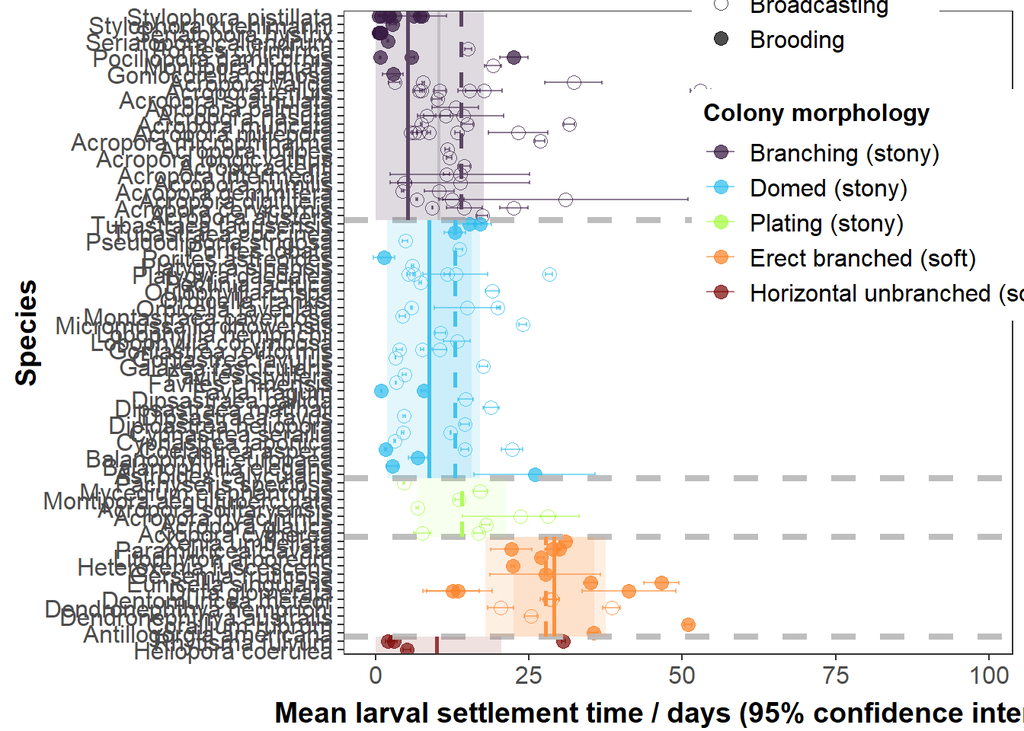

```r
# Create plot
fig4a <- ggplot(settlement_plotting, aes(x = pld_av_comp_effectsize_d, y = fct_reorder(species_accepted, morph_id, .desc = TRUE), shape = spawn_mode, colour = growth_form_cat)) + # Plot species, grouped by morphology, against mean larval settlement time, with shape and colour differentiating reproductive mode and morphology
  geom_errorbar(aes(xmin = comp_lb, xmax = comp_ub), alpha = 0.55, width = 0.5) + # Add error bars for data points
  geom_point(alpha = 0.7, size = 3) + # Set point size and transparency
  geom_hline(yintercept = 2.5, colour = "grey", linetype = 2, linewidth = 1.5) +
  geom_hline(yintercept = 14.5, colour = "grey", linetype = 2, linewidth = 1.5) +
  geom_hline(yintercept = 21.5, colour = "grey", linetype = 2, linewidth = 1.5) +
  geom_hline(yintercept = 52.5, colour = "grey", linetype = 2, linewidth = 1.5) + # Use dashed lines to separate out morphologies
  geom_segment(aes(x = 5.264, y = 77.5, yend = 52.5), colour = "#5C4564", linewidth = 1) + # Add vertical lines for overall means for each life-history grouping, and show confidence interval
  annotate(geom = "rect", xmin = 0.001, xmax = 10.526   ,
           ymin = 77.5, ymax = 52.5,
           fill = "#5C4564", alpha = 0.2) +
  geom_segment(aes(x = 13.873, y = 77.5, yend = 52.5), colour = "#5C4564", linetype = 2, linewidth = 1) +
  annotate(geom = "rect", xmin = 10.043, xmax = 17.703,
           ymin = 77.5, ymax = 52.5,
           fill = "#5C4564", alpha = 0.2) +
  geom_segment(aes(x = 8.740, y = 52.5, yend = 21.5), colour = "#41C3EE", linewidth = 1) +
  annotate(geom = "rect", xmin = 1.838, xmax = 15.642,
           ymin = 21.5, ymax = 52.5,
           fill = "#41C3EE", alpha = 0.15) +
  geom_segment(aes(x = 12.988, y = 52.5, yend = 21.5), colour = "#41C3EE", linetype = 2, linewidth = 1) +
  annotate(geom = "rect", xmin = 8.889, xmax = 17.088,
           ymin = 21.5, ymax = 52.5,
           fill = "#41C3EE", alpha = 0.15) +
  geom_segment(aes(x = 14.093, y = 14.5, yend = 21.5), colour = "#AFFC57", linetype = 2, linewidth = 1) +
  annotate(geom = "rect", xmin = 6.865, xmax = 21.321,
           ymin = 14.5, ymax = 21.5,
           fill = "#AFFC57", alpha = 0.1) +
  geom_segment(aes(x = 29.112, y = 2.5, yend = 14.5), colour = "#FB9140", linewidth = 1) +
  annotate(geom = "rect", xmin = 17.870, xmax = 37.574,
           ymin = 2.5, ymax = 14.5,
           fill = "#FB9140", alpha = 0.15) +
  geom_segment(aes(x = 27.722, y = 2.5, yend = 14.5), colour = "#FB9140", linetype = 2, linewidth = 1) +
  annotate(geom = "rect", xmin = 22.523, xmax = 35.701,
           ymin = 2.5, ymax = 14.5,
           fill = "#FB9140", alpha = 0.15) +
  geom_segment(aes(x = 9.922, y = 0.5, yend = 2.5), colour = "#973939", linewidth = 1) +
  annotate(geom = "rect", xmin = 0, xmax = 20.537,
           ymin = 0.5, ymax = 2.5,
           fill = "#973939", alpha = 0.15) +
  scale_shape_manual(values = repro_shape_set,
                     name = "Reproductive mode") + # Set point shapes manually
  scale_colour_viridis_d(option = "H", name = "Colony morphology") + # Use an accessible colour pallette
  theme_bw() + # Set theme manually
  guides(
    shape = guide_legend(order = 1),
    colour = guide_legend(order = 2)
  ) +
  theme(panel.grid = element_blank(),
        axis.title = element_text(size = 14, face = "bold"),
        axis.title.y = element_text(vjust = 0.5),
        axis.title.x = element_text(vjust = -0.5),
        axis.text.y = element_text(size = 12),
        axis.text.x = element_text(size = 12),
        plot.title = element_text(size = 14, colour = "black", face = "bold"),
        legend.text = element_text(size = 12),
        legend.title = element_text(size = 12, colour = "black", face = "bold"),
        legend.position = "inside",
        legend.position.inside = c(0.8, 0.814)) +
  labs(x = "Mean larval settlement time / days (95% confidence interval)",
       y = "Species")  # Label axes

#View figure
fig4a
```

```r
#Save figure
ggsave("figures/fig4a.png", width = 12, height = 17)
```

Make figure for survival times (4b). No vertical lines needed for averages.

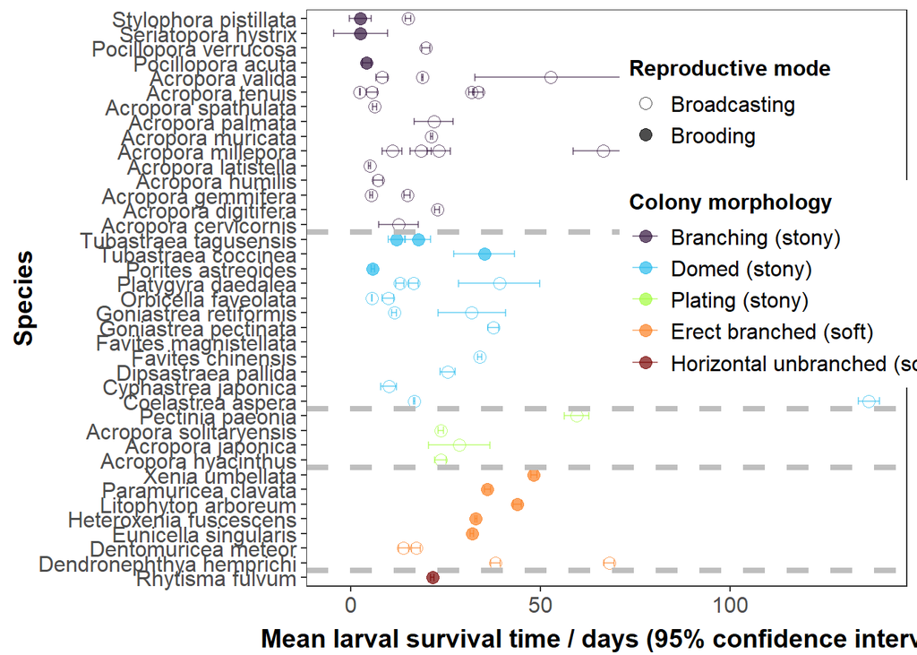

```r
# Create figure
fig4b <- ggplot(survival_plotting, aes(x = pld_av_mort_effectsize_d, y = fct_reorder(species_accepted, morph_id, .desc = TRUE), shape = spawn_mode, colour = growth_form_cat)) +
  geom_errorbar(aes(xmin = surv_lb, xmax = surv_ub), alpha = 0.55, width = 0.5) +
  geom_point(alpha = 0.7, size = 3) +
  geom_hline(yintercept = 1.5, colour = "grey", linetype = 2, linewidth = 1.5) +
  geom_hline(yintercept = 8.5, colour = "grey", linetype = 2, linewidth = 1.5) +
  geom_hline(yintercept = 12.5, colour = "grey", linetype = 2, linewidth = 1.5) +
  geom_hline(yintercept = 24.5, colour = "grey", linetype = 2, linewidth = 1.5) +
  scale_shape_manual(values = repro_shape_surv,
                     name = "Reproductive mode") +
  scale_colour_viridis_d(option = "H", name = "Colony morphology") +
  theme_bw() +
  guides(
    shape = guide_legend(order = 1),
    colour = guide_legend(order = 2)
  ) +
  theme(panel.grid = element_blank(),
        axis.title = element_text(size = 14, face = "bold"),
        axis.title.y = element_text(vjust = 0.5),
        axis.title.x = element_text(vjust = -0.5),
        axis.text.y = element_text(size = 12),
        axis.text.x = element_text(size = 12),
        plot.title = element_text(size = 14, colour = "black", face = "bold"),
        legend.text = element_text(size = 12),
        legend.title = element_text(size = 12, colour = "black", face = "bold"),
        legend.position = "inside",
        legend.position.inside = c(0.8, 0.64)) +
  labs(x = "Mean larval survival time / days (95% confidence interval)",
       y = "Species")

# View figure
fig4b
```

```r
# Save figure
ggsave("figures/fig4b.png", width = 12, height = 9)
```